# A Regression Analysis on The Efects of The Risk of Infection and on The Length of Stay in Hospitals

Rumil Legaspi, Rumil.legaspi@gmail.com

Mei Leng Lao, Email

28 February 2021

# **Purpose**

We are conducting a simple linear regression model from the SENIC dataset to analyze the relationship of the explanatory variable, infection of risk(INFRISK) and the response variable, length of stay(LOS).

# **Our Data**

## Quick background on Dataset and variable

```r
#Setting up our work environment
setwd("C:/Users/RUMIL/Desktop/APU/STAT 511 - Millie Mao (Applied Regression Analysis)/Project 1/Project 1")

#Loading in the data
load(file = "SENIC.rdata")

Infection_data <- data.frame("SENIC.rdata")

#Defining and renaming our Explanatory(X) and Response(Y) variables
infection_risk = SENIC$INFRISK #X
length_of_stay = SENIC$LOS #Y
```

**(delete this)** some interpretations:

- Length of stay is explained by the average estimated probability of acquiring infection in hospital.
- As the risk of infection increases the average length of stay in the hospital also increases.

# **Part 1: Interpretation and Parameter Inference**

## Estimated Linear Regression Function

```r
install.packages("formatR")
library(formatR)
```

**$\beta_{0}$ = 6.3368 *(intercept)***

**$\beta_{1}$ = 0.7604 *(slope)***

and the estimated regression equation to be:

**$\hat{Y}= 6.3368 + 0.7604X$**

## Fitting on Scatterplots

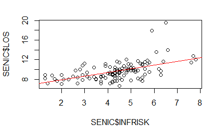

```r
plot(SENIC$INFRISK, SENIC$LOS)
abline(infection_lm, col = "red")
```

## Interpretting Regression Coefficients & $R^2$

**From our model we derive that our intercept, $\beta_{0}$ = 6.3368**:

This indicates where our response output lies when there is no input or when $X$ is 0. In other words, when risk of infection (explanatory variable) is at 0, the average length of stay of patients in a hospital is roughly 6 days.

Analyzing the intercept on its own might be confusing and at times misleading. In understanding the context of our data we can see that despite patients having an average estimated probability of acquiring an infection in a hospital be 0% we know that this is impossible. Additionally we know that it is possible for patients to be in the hospital for roughly 6 days for other medical reasons.

In other words, although a bit misleading at first glance, when risk of infection is close to zero and almost nonexistent, there is still truth in a patient having a prolonged length of stay in a hospital.

**Our slope, $\hat{\beta_1} = 0.7604$**:

**Our $R^2=0.2846$**:

***The R squared found at $0.2846$ indicates that the risk of infection (input variable) helps explain close to 28% of the variability in our response variable, length of stay. In other words, **the relationship between our model and the dependent variable length of stay is fairly weak.**

## Hypothesis Testing on our Slope to Test Significance

Our null hypothesis is that there is no linear relationship

**Null Hypothesis**: ${H_0}$: $\beta_{1} = 0$ (slope is horizontal/ no relationship), in other words there is no linear relationship between risk of infection and length of stay

**Alternative Hypothesis**: ${H_1}$: $\beta_{1} \neq 0$ (slope exists/ relationship exists), there is linear relationship either positive or negative between risk of infection and length of stay.

### Conducting a T-test ***(is this even necessary?)

```r
#Using qt() in R we get

qt(0.975, 111)
```

```
[1] 1.981567
```

Our critical value is 1.981567

Now comparing the absolute value of the t-statistic of $t= 6.645$ to the slope ($\beta_{1}$) of risk of infection with our critical value 1.981567

|6.645| > 1.981567

we can conclude that because the absolute value of our t-statistic is greater than our critical value, we reject the null hypothesis and conclude with our alternative hypothesis that **a relationship exists between risk of infection(x) and length of stay(Y).**

### Finding the 95% Confidence Interval of the Slope

```r
#alpha at 0.05
alpha <- 0.05

#constructing our 95% confidence interval
confint(infection_lm, level = 1 - alpha)
```

```
                   2.5 %    97.5 %
(Intercept)    5.3038443 7.3697288
infection_risk 0.5336442 0.9871976
```

#### Interpretation

This output reads that within our confidence interval from 2.5% (the lower limit of our interval) to 97.5% (the upper limit of our interval), our intercept and **slope** are both found within the listed intervals.

In this case if we repeat this experiment many times, the true population parameter of our slope $\beta_{1}$ will be between the interval 0.5336442 and 0.9871976 with 95% confidence and $\alpha$ (accepted error) of 5%

0 is not included in our interval, but we are interested in it because if zero was included in our confidence interval then that would indicate (that there is a chance that) no change/relationship and would make risk of infection(INRFRISK) a bad predictor for length of stay(LOS). So in this case, since 0 is not included, we can conclude that there is change.

# **Part 2: Point and interval estimation**

```r
#Creating a new single observation where risk is 5
new_infection_data <- data.frame(infection_risk = 5)

#Constructing our prediction interval
ci_infection_5 <- predict(infection_lm, new_infection_data,
                          interval = "confidence", level = 1 - alpha )

ci_infection_5
```

```
       fit      lwr      upr
1 10.13889 9.802655 10.47513
```

## Confidence Interval Interpretation when INFRISK = 5

The fitted value of the length of stay variable when the risk of infection **is at 5% is 10.13889.**

This 95% confidence interval when risk of infection **is at 5% is from 9.802 to 10.475.**

In other words, when the risk of infection is 5%, we can expect the **average(true mean)** of the length of stay (response variable) to be within the intervals of **roughly 9 to 10 and a half days with 95% confidence.**

## Constructing a Prediction Interval

We can use a prediction interval when trying to find where an individual observation will fall. Lets construct a prediction interval given risk of infection is at 5 percent.

```r
#Constructing prediction interval when INFRISK is 5
pi_infection_5 <- predict(infection_lm, new_infection_data,  interval = "prediction", level = 1 - alpha )

pi_infection_5
```

```
       fit      lwr      upr
1 10.13889 6.903222 13.37456
```

## Prediction Interval Interpretation

***From the results we can predict with 95% confidence that when a patient has a risk of infection at 5%, her length of stay will fall somewhere between 6.903 and 13.37 days. (should I say roughly 7 days to 13 days?)

# **Part 3: Diagnostics**

## Our Assumptions

To ensure our model is still within the bounds of our made assumptions for a linear regression model lets plot them using different plotting methods.

lets recall our made assumptions for a linear regression model:

- **L** inearity
- **I** ndependence
- **N** ormality of the errors
- **E** qual error variance for all values of X (homoskedasticity)

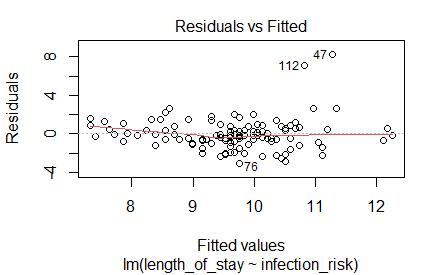

```r
#plotting scatterplots to check assumption
plot(infection_lm , which = c(1))
```

```r
?plot()
```

### ***Testing Linearity

We cannot see a clear violation of linearity assumption in our **residual vs fitted plot** since we do not see a systematic pattern.

### ***Independence residuals vs time

```r
#Checking to independence

#install.packages("MASS")
#library(MASS)
#infection.resid = studres(infection_lm)

#Studentized residuals vs. predictor
#plot(SENIC$infection_risk, infection.resid)

#Residuals vs. Order
#data.order = c(1:25)
#plot(data.order, )
```

## Testing Normality

### Plotting to Check for Normality and Equal Variance Assumptions

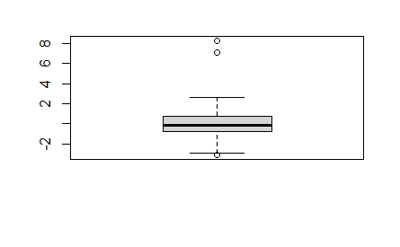

```r
#Plotting a boxplot and #histogram
boxplot(infection_lm$residuals)
```

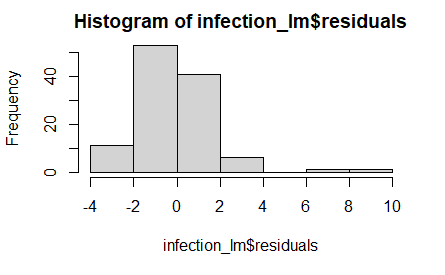

```r
hist(infection_lm$residuals)
```

## Boxplot and Histogram Interpretation

### Stating our Hypothesis

**Null Hypothesis**: ${H_0}$: The data **is** from a normal distribution

**Alternative Hypothesis**: ${H_1}$: The data is **NOT** from a normal distribution

### Testing our Hypothesis

**To test these we can use several normality tests using…**

- Shapiro-Wilk normality test
- Shapiro-Francia normality test
- Anderson-Darling normality test

These tests focus mainly on the usage of regression residuals with an p-value as an output useful for hypothesis testing. **Are main goal is to see if our data truly follows a normal distribution.**

```r
#Shapiro-Wilk normality test
shapiro.test(infection_lm$residuals)
```

```
    Shapiro-Wilk normality test

data:  infection_lm$residuals
W = 0.87054, p-value = 1.699e-08
```

```r
#Shapiro-Francia normality test
nortest::sf.test(infection_lm$residuals)
```

```
    Shapiro-Francia normality test

data:  infection_lm$residuals
W = 0.86188, p-value = 7.85e-08
```

```r
#Anderson-Darling normality test
nortest::ad.test(infection_lm$residuals)
```

```
    Anderson-Darling normality test

data:  infection_lm$residuals
A = 2.008, p-value = 3.823e-05
```

## Interpretation of Normality Tests

### Plotting to Check for Equal Variance Assumptions

## Testing Equal Variance Assumptions

### Stating our Hypothesis

**Null Hypothesis**: ${H_0}$: The variances in the data **is** equal **Alternative Hypothesis**: ${H_1}$: The variances in the data are **NOT** equal

### ***Testing our Hypothesis

We dont want to see fan shapes otherwise they violate equal variance assumption

we want equal spread

[figure not shown]

## Checking for omitted predictors

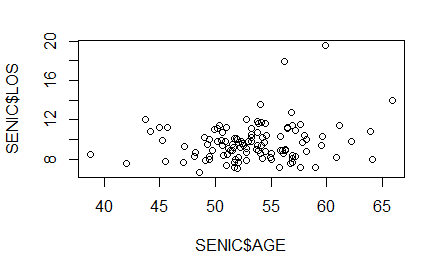

```r
#scatterplot
plot(SENIC$AGE, SENIC$LOS)
```

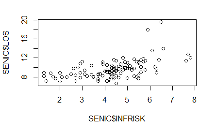

```r
plot(SENIC$INFRISK, SENIC$LOS)
```

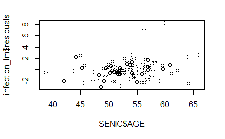

```r
#Regress volume on Height (SLR model)
plot(SENIC$AGE, infection_lm$residuals)
```